# Code for: Finite mixture models for trajectory analysis of in-hospital routinely laboratory values: application as biomarkers in spinal cord injury patients

## Experiment II

**Not run during knitting**

```r
exp_II_list<-list()
for (cutoff in c(1,3,7,14,21)){

  cat("Exp II, cutoff:", cutoff, "\n")
  mimic_modeling_set_cut<-mimic_modeling_set_f%>%
    filter(time_days<=cutoff)
  modeling_set_cut_list<-split(mimic_modeling_set_cut,mimic_modeling_set_cut$label)

  predict_list<-list()
  for (i in 1:length(GMM_list)){
    print(i)
    model<-GMM_list[[i]]
    analyte<-str_split(names(GMM_list)[i], "_", simplify = T)[,4]
    pre_data<-modeling_set_cut_list[[analyte]]

    if(model$ng == 1){
      next()
    }

    pprob<-predictClass(model, pre_data, "subject_id_num")

    if(ncol(pprob) == 4){
      pprob$prob3<-NA
    }else if(ncol(pprob) ==3){
      pprob$prob2<-NA
      pprob$prob3<-NA
    }
    pprob$analyte<-analyte

    predict_list[[i]]<-pprob
  }

  predict_df<-do.call(rbind,predict_list)%>%
    left_join(subject_id_df)%>%
    left_join(mimic_patients_all)%>%
    filter(!analyte %in%c("Bicarbonate", "Calcium, Total", "Creatinine"))%>%
    select(prob1, prob2, prob3, analyte, subject_id, cohort_group)%>%
    filter(cohort_group != "SCI_noFracture")%>%
    mutate(is_SCI = ifelse(cohort_group == "SCI_Fracture", "yes", "no"))%>%
    pivot_wider(id_cols =c(subject_id, is_SCI),
              names_from = analyte, values_from = c(prob1, prob2, prob3))

  predict_df<-predict_df%>%
    select(-all_of(names(which(sapply(predict_df,
                                      function(x) mean(is.na(x)))==1))))%>%
    filter(complete.cases(.))

  exp_II_list[[as.character(cutoff)]]<-run_experiment(predict_df, "is_SCI",
                                       n.yes.train = 120,
                                       n.no.train = 800)
}

saveRDS(exp_II_list, "prediction_experiments/exp_II_list.RDS")
```

### Extract performance

```r
exp_II_list<-readRDS("prediction_experiments/exp_II_list.RDS")

exp_II_list<-exp_II_list[which(sapply(exp_II_list, function(x) !is.null(x)))]
performance_df<-mapply(function(i, name_i){

  temp_df<-lapply(1:25, function(j){
    df<-as.data.frame(rbind(i$train_list[[j]]$cMatrix$byClass,
              i$test_list[[j]]$cMatrix$byClass))
    df$auc<-c(i$train_list[[j]]$roc$auc,i$test_list[[j]]$roc$auc)
    df$per_type<-c("in-train", "out-train")
    df$cutoff<-name_i

    return(df)
  })

  temp_df<-do.call(rbind, temp_df)
  temp_df
},exp_II_list, names(exp_II_list), SIMPLIFY = F)

exp_II_per_df<-do.call(rbind, performance_df)
```

**Performance figure**

```r
exp_II_auc_plot<-exp_II_per_df%>%
  mutate(cutoff = factor(cutoff, levels = c(1,3,7,14,21),
                         labels = c("<= 1 days", "<= 3 days","<= 7 days","<= 14 days","<= 21 days")))%>%
ggplot(aes(per_type, auc, fill = per_type))+
  geom_boxplot()+
  ylim(0.5,1)+
  xlab(NULL)+ylab("AUC")+
  facet_grid(~cutoff)+
  theme_minimal()+
  theme(axis.text.x = element_blank(), legend.title = element_blank(),
        legend.position = "bottom", legend.margin = margin(t = -10))+
  ggtitle("Exp II: has SCI")
```

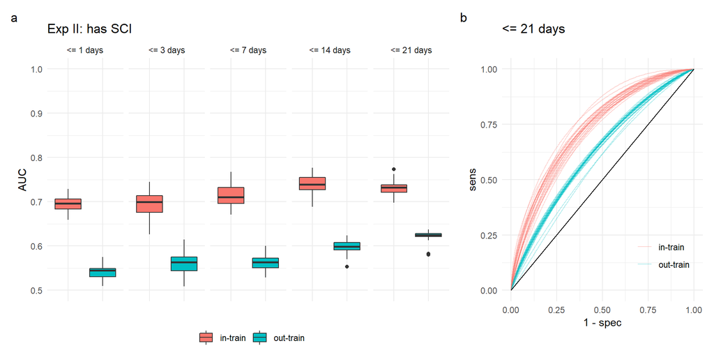

```r
II_roc_21<-exp_II_list[["21"]]$roc_plot+
  ggtitle("<= 21 days")+
  theme(legend.title = element_blank(), legend.position = c(0.8, 0.2))

fig_expII<-exp_II_auc_plot+II_roc_21
fig_expII_layout<-c(
  area(1, 1,r = 2),area(1,l =3)
)

fig_expII<- fig_expII+plot_annotation(tag_levels = "a")+plot_layout(design = fig_expII_layout)

fig_expII
```

```r
ggsave(plot = fig_expII, "figures/fig_expII.png", width = 7, height = 3)
```

## Experiment III

Experiment III makes use of a dataset obtained from the TRACK-SCI study. Data is not provided and therefore code will not run.

### TRACK-SCI labs

```r
#TRACK-SCI labs data from TRACK-SCI provided file
track_sci_lab_raw<-read.csv("data/TRACKSCI/TRACK-SCI labs.csv")

## Data frame structure
str(track_sci_lab_raw)
```

```
## 'data.frame':    74722 obs. of  7 variables:
##  $ Study_ID          : int  1001 1001 1001 1001 1001 1001 1001 1001 1001 1001 ...
##  $ Injury_datetime   : chr  "5/8/2015 22:11" "5/8/2015 22:11" "5/8/2015 22:11" "5/8/2015 22:11" ...
##  $ result_datetime   : chr  "6/2/2015 11:42" "6/9/2015 4:35" "5/10/2015 3:12" "5/11/2015 3:21" ...
##  $ Discharge_datetime: chr  "6/15/2015 14:00" "6/15/2015 14:00" "6/15/2015 14:00" "6/15/2015 14:00" ...
##  $ lab_name          : chr  "% saturation" "absolute cd4 t cells" "activated ptt" "activated ptt" ...
##  $ ord_value_num     : num  10 106 34.1 43.9 47.2 44.7 50.7 39 71.7 71.1 ...
##  $ Time_from_Injury  : int  35371 45024 1741 3190 4644 6064 10459 13324 14109 14389 ...
```

We can observe the dataset for the lab assays is organized in long-view, with laboratory names in one column, values in another and time in another column. The variables of interest are:

- `Study.ID`: unique identifier for a subject following study de-ID number.
- `lab_name`: Name of the lab assay based on EHR extraction.
- `ord_value_num`: value of the specific ordered lab assay.
- `Time_From_Injury`: calculated time in minutes from the injury to the lab assay.

We are going to perform some wrangling and cleaning of the data before we continue to help with downstream processing. We create a new dataset to keep the raw data untouched.

**Here:**

```r
track_sci_lab_df<-track_sci_lab_raw%>%
  mutate(Study_ID = as.factor(Study_ID),
         Injury_datetime = as.Date(Injury_datetime,format = "%m/%d/%Y %H:%M"),
         result_datetime = as.Date(result_datetime,format = "%m/%d/%Y %H:%M"),
         Discharge_datetime = as.Date(Discharge_datetime, format = "%m/%d/%Y %H:%M"))%>%
  rename(value = ord_value_num)
```

#### Summary

```r
summary_track_sci_labs<-track_sci_lab_df%>%
  filter(!is.na(value))%>%
  group_by(lab_name, Study_ID)%>%
  summarise(n=n(), var_value = var(value, na.rm = T))%>%
  group_by(lab_name)%>%
  summarise(mean_times_n=mean(n),max_times_n = max(n), n_subjects = n(),
            mean_var=mean(var_value, na.rm = T))%>%
  arrange(desc(n_subjects), desc(mean_var))

summary_track_sci_labs%>%
  datatable()
```

|  | lab_name | mean_times_n | max_times_n | n_subjects | mean_var |
| --- | --- | --- | --- | --- | --- |
| 1 | platelet count | 15.5766423357664 | 94 | 137 | 12689.9069977917 |
| 2 | glucose | 16.2043795620438 | 102 | 137 | 840.442933006246 |
| 3 | bun | 16.1021897810219 | 102 | 137 | 43.6461243235789 |
| 4 | hematocrit (%) of blood | 15.5912408759124 | 94 | 137 | 15.3250600353596 |
| 5 | chloride (mmol/l) in ser/plas | 16.1970802919708 | 102 | 137 | 12.2874120833372 |
| 6 | co2 | 16.1970802919708 | 102 | 137 | 9.04809042098371 |
| 7 | neutrophils (10*3/ul) in blood by automated count | 7.73722627737226 | 38 | 137 | 8.43811216072779 |
| 8 | wbc count | 15.5693430656934 | 94 | 137 | 8.3282770705311 |
| 9 | sodium (mmol/l) in ser/plas | 16.6058394160584 | 102 | 137 | 8.18961647596868 |
| 10 | anion gap (no k) | 16.1751824817518 | 102 | 137 | 5.48489396505631 |

[output cut: 222 more lines]

**Read laboratory dictionary:** Name equivalence between TRACK-SCI and MIMIC modeling set analytes has been mapped manually.

```r
track_lab_list<-read.csv("data/TRACKSCI/modeling_set track to mimic.csv")

track_sci_lab_df_f<-track_sci_lab_df%>%
  filter(lab_name %in% track_lab_list$lab_name)

for (i in 1:nrow(track_sci_lab_df_f)){
  lab_name<-track_sci_lab_df_f$lab_name[i]

  new_name<-track_lab_list$new_name[which(lab_name == track_lab_list$lab_name)]
  track_sci_lab_df_f$lab_name[i]<-new_name
}
```

#### Preprocessing

Pre processing of the TRACK-SCI data as we performed for MIMIC

```r
track_sci_lab_df_f<-track_sci_lab_df_f%>%
  mutate(time_days = Time_from_Injury/1440)%>%
  filter(time_days<=21, value>0)

## custom function
extreme_deletion<-function(x, prob = c(0.2,0.8), factor = 1.5){
  down<-quantile(x, prob[1])-factor*IQR(x)
  up<-quantile(x, prob[2])+factor*IQR(x)

  x<-ifelse(x>up, NA,x)
  x<-ifelse(x<down, NA,x)

  return(x)
}

track_sci_lab_df_f<-track_sci_lab_df_f%>%
  arrange(time_days)%>%
  group_by(lab_name, Study_ID)%>%
  mutate(value_clean = extreme_deletion(value),
         out = ifelse(is.na(value_clean), 1,0),
         subject_id_num = as.numeric(Study_ID))%>%
  filter(out == 0)
```

**TRACK-SCI spaghetti plots**

```r
track_spaghetti_plot<-track_sci_lab_df_f%>%
ggplot(aes(time_days, value_clean, group = Study_ID))+
  geom_line()+
  facet_wrap(~lab_name, scales = "free")+
  ylab("Anlyte value")+xlab("Days from arrival")+
  theme_minimal()

ggsave("figures/track_modeling_set.png", track_spaghetti_plot,
       height = 6, width = 10)
```

**Load the outcome data**

```r
outcome_df<-read.csv("data/TRACKSCI/outcomes_TRACKSCI.csv")
outcome_df<-outcome_df%>%
  mutate(Study_ID = as.factor(Study_ID),
         subject_id_num = as.numeric(Study_ID))
```

### Predict TRACK data

```r
track_minimal_list<-track_sci_lab_df_f%>%
  arrange(lab_name)%>%
  split(.$lab_name)
```

**Helper function to run experiment III**

```r
run_experimentIII<-function(prediction_df, target.name, seed = 555){
  set.seed(seed)

  exp_fit_list<-list()
  exp_test_list<-list()

  for (i in 1:nrow(prediction_df)){
    print(i)

    Y<-as.factor(unlist(prediction_df[-i,target.name]))
    X<-as.data.frame(prediction_df[-i,3:ncol(prediction_df)])

    X_test<-as.data.frame(prediction_df[i,3:ncol(prediction_df)])
    Y_test<-as.factor(unlist(prediction_df[i,target.name]))

    fit<-train( x = X, y = Y, method = "glmnet",
            trControl = trainControl(method = "cv",number = 3,
                                     classProbs = TRUE))

    exp_fit_list[[i]]<-pred_performance(fit, X, Y, positive = "AB", negative = "CDE")
    exp_test_list[[i]]<-list("Y_test" = Y_test, "Y_pred" = predict(fit, X_test, type = "prob"))
  }

  ## In-training prediction performance
  in_train_r_curve<-lapply(exp_fit_list, function(x){
    data.frame(sens = x$roc$sensitivities, spec = x$roc$specificities,
               pre_type = "in-train")
  })

  in_train_r_curve<-do.call(rbind, in_train_r_curve)
  in_train_r_curve$id<-rep(1:(length(in_train_r_curve)/514), each = 514)

  ## out-train prediction performance
  out_train_r_curve<-lapply(exp_test_list, function(x){
    data.frame(x$Y_pred)
  })

  out_train_r_curve<-do.call(rbind, out_train_r_curve)
  Y_test<-unlist(lapply(exp_test_list, function(x){
    data.frame(x$Y_test)
  }))

  out_train_r_curve<-pROC::roc(Y_test,out_train_r_curve[,"CDE"], smooth = T)
  out_train_r_curve<-data.frame(sens = out_train_r_curve$sensitivities,
                                spec = out_train_r_curve$specificities,
                                pre_type = "LOOCV", id = rep(1,514))

  r_curve<-rbind(in_train_r_curve, out_train_r_curve)

  line_df<-data.frame(x = c(0,1), y = c(0,1))
  roc_plot<-ggplot(r_curve, aes(1-spec, sens, color =  pre_type, group = id))+
    geom_path(alpha = 0.3)+
    geom_line(data = line_df, aes(x, y), inherit.aes = F)+
    theme_minimal()

  return(list("train_list" = exp_fit_list, "test_list" = exp_test_list,
              "roc_plot" = roc_plot))
}
```

**Not run during knitting**

```r
exp_III_list<-list()
for (cutoff in c(1,3,7,14,21)){

  cat("Exp III, cutoff:", cutoff, "\n")
  track_modeling_set_cut<-track_sci_lab_df_f%>%
    filter(time_days<=cutoff)
  modeling_set_cut_list<-split(track_modeling_set_cut,track_modeling_set_cut$lab_name)

  predict_list<-list()
  for (i in 1:length(GMM_list)){
    print(i)
    model<-GMM_list[[i]]
    analyte<-str_split(names(GMM_list)[i], "_", simplify = T)[,4]
    pre_data<-as.data.frame(modeling_set_cut_list[[analyte]])

    if(nrow(pre_data) == 0){
      next()
    }

    if(model$ng == 1){
      next()
    }

    pprob<-predictClass(model, pre_data, "subject_id_num")

    if(ncol(pprob) == 4){
      pprob$prob3<-NA
    }else if(ncol(pprob) ==3){
      pprob$prob2<-NA
      pprob$prob3<-NA
    }
    pprob$analyte<-analyte

    predict_list[[i]]<-pprob
  }

  predict_df<-do.call(rbind,predict_list)%>%
    left_join(outcome_df)%>%
    filter(!analyte %in%c("Bicarbonate", "Calcium, Total", "Creatinine"))%>%
    select(prob1, prob2, prob3, analyte, Study_ID, latest_AIS_at_hospital)%>%
    mutate(AIS_binary = ifelse(latest_AIS_at_hospital %in% c("A", "B"), "AB","CDE"))%>%
    pivot_wider(id_cols =c(Study_ID, AIS_binary),
              names_from = analyte, values_from = c(prob1, prob2, prob3))

  predict_df<-predict_df%>%
    select(-all_of(names(which(sapply(predict_df,
                                      function(x) mean(is.na(x)))==1))))%>%
    filter(complete.cases(.))

  exp_III_list[[as.character(cutoff)]]<-run_experimentIII(predict_df, "AIS_binary")
}

saveRDS(exp_III_list, "prediction_experiments/exp_III_list.RDS")
```

**Extract performance**

```r
exp_III_list<-readRDS("prediction_experiments/exp_III_list.RDS")

exp_III_list<-exp_III_list[which(sapply(exp_III_list, function(x) !is.null(x)))]
performance_df<-mapply(function(i, name_i){

  temp_df<-lapply(1:length(i), function(j){

    df<-as.data.frame(rbind(i$train_list[[j]]$cMatrix$byClass))
    df$auc<-c(i$train_list[[j]]$roc$auc)
    df$per_type<-c("in-train")
    df$cutoff<-name_i

    return(df)
  })

  Y_test_prob<-do.call(rbind, lapply(i$test_list, function(x){
    x$Y_pred
  }))

  Y_test<-do.call(rbind, lapply(i$test_list, function(x){
    as.character(x$Y_test)
  }))

  Y_roc<-pROC::roc(as.factor(Y_test),Y_test_prob[,"CDE"], smooth = T)
  prediction<-ifelse(Y_test_prob[,"CDE"]>0.5, "CDE", "AB")

  test_df<-as.data.frame(rbind(confusionMatrix(as.factor(prediction), as.factor(Y_test), positive = "CDE")$byClass))
  test_df$auc<-Y_roc$auc
  test_df$per_type<-"LOOCV"
  test_df$cutoff<-name_i

  temp_df<-do.call(rbind, temp_df)
  temp_df<-rbind(temp_df, test_df)
  temp_df

},exp_III_list, names(exp_III_list), SIMPLIFY = F)

exp_III_per_df<-do.call(rbind, performance_df)
```

**Performance figure**

```r
exp_III_auc_plot<-exp_III_per_df%>%
  mutate(cutoff = factor(cutoff, levels = c(1,3,7,14,21),
                         labels = c("<= 1 days", "<= 3 days","<= 7 days","<= 14 days","<= 21 days")))%>%
ggplot(aes(per_type, auc, fill = per_type))+
  geom_boxplot()+
  ylim(0.5,1)+
  xlab(NULL)+ylab("AUC")+
  facet_grid(~cutoff)+
  theme_minimal()+
  theme(axis.text.x = element_blank(), legend.title = element_blank(),
        legend.position = "bottom", legend.margin = margin(t = -10))+
  ggtitle("Exp III: last AIS in-hospital (AB vs. CDE)")
```

```r
III_roc_21<-exp_III_list[["21"]]$roc_plot+
  ggtitle("<= 21 days")+
  theme(legend.title = element_blank(), legend.position = c(0.8, 0.2))

fig_expIII<-exp_III_auc_plot+III_roc_21
fig_III_layout<-c(
  area(1, 1,r = 2),area(1,l =3)
)

fig_expIII<- fig_expIII+plot_annotation(tag_levels = "a")+plot_layout(design = fig_III_layout)

ggsave(plot = fig_expIII, "figures/fig_expIII.png", width = 7, height = 3)
```

# ANNEX

## Data simulation for figures

**One class exampla**

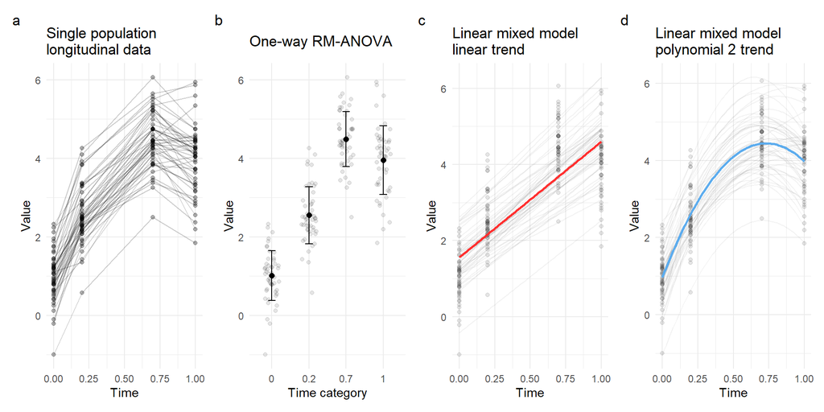

```r
set.seed(555)
color_class<-c("firebrick1", "steelblue2", "purple")


one_class_sim <- latrend::generateLongData(sizes = 50, id = "Id",
                            data = data.frame(Time = c(0,0.2,0.7,1)),
                            cluster = ~poly(Time, 2, raw = TRUE),
                            clusterCoefs = cbind(c(1, 9, -6)),
                            noiseScales = c(0.4),
                            randomScales = cbind(0.6),
                            clusterNames = "Class 1")

figXa<-ggplot(one_class_sim, aes(Time, Value, group = Id))+
  geom_line(alpha = 0.2)+
  geom_point(alpha = 0.3)+
  theme_minimal()+
  ggtitle("Single population\nlongitudinal data")

figXb<-ggplot(one_class_sim, aes(factor(Time), Value, group = factor(Time)))+
  geom_jitter(alpha=0.1, width = 0.2)+
  stat_summary(fun = "mean", geom = "point", size = 2)+
  stat_summary(fun.data = mean_sdl, fun.args = list("mult" = 1),geom = "errorbar", width = 0.2)+
  theme_minimal()+
  xlab("Time category")+
  ggtitle("One-way RM-ANOVA")

figXc<-ggplot(one_class_sim, aes(Time, Value, group = Id))+
  geom_point(alpha = 0.1)+
  stat_smooth(geom = "line", method = "lm", se = F, alpha = 0.05)+
  geom_smooth(aes(group = Class, color = Class), method = "lm", se = F, size = 1)+
  scale_color_manual(values = color_class[1])+
  theme_minimal()+
  theme(legend.position = "none")+
  ggtitle("Linear mixed model\nlinear trend")

figXd<-ggplot(one_class_sim, aes(Time, Value, group = Id))+
  geom_point(alpha = 0.1)+
    stat_smooth(geom = "line", method = "lm", se = F, formula = y~poly(x,2), alpha = 0.05)+
  geom_smooth(aes(group = Class, color = Class), method = "lm", se = F, formula = y~poly(x,2), size = 1)+
  scale_color_manual(values = color_class[2])+
  theme_minimal()+
  theme(legend.position = "none")+
  ggtitle("Linear mixed model\npolynomial 2 trend")

figX<-figXa+figXb+figXc+figXd

figX<-figX+plot_layout(nrow = 1)+plot_annotation(tag_levels = "a")

figX
```

```r
ggsave("figures/figX.png", width = 12, height = 4)
```

**More than one class**

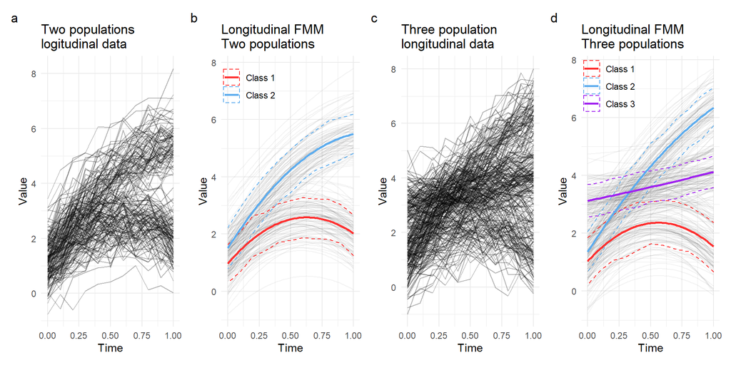

```r
set.seed(555)
two_class_sim <- latrend::generateLongData(sizes = c(100, 80), id = "Id",
                            cluster = ~poly(Time, 2, raw = TRUE),
                            clusterCoefs = cbind(c(1, 5, -4), c(1.5, 7, -3)),
                            noiseScales = c(0.4, 0.4),
                            randomScales = cbind(0.6, 0.6),
                            clusterNames = c("Class 1", "Class 2"))

figX1a<-ggplot(two_class_sim, aes(Time, Value, group = Id))+
  geom_line(alpha = 0.3)+
  theme_minimal()+
    ggtitle("Two populations\nlogitudinal data")


figX1b<-ggplot(two_class_sim, aes(Time, Value, group = Id))+
  stat_smooth(geom = "line", method = "lm", se = F, formula = y~poly(x,2), alpha = 0.05)+
  stat_summary(fun.data = mean_sdl, fun.args = list("mult" = 1), geom = "ribbon", aes(group = Class, color = Class), alpha = 0, linetype = "dashed")+
  geom_smooth(aes(group = Class, color = Class), method = "lm", se = F, formula = y~poly(x,2), size = 1)+
  scale_color_manual(values = color_class)+
  theme_minimal()+
  theme(legend.position = c(0.2,0.9), legend.title = element_blank())+
    ggtitle("Longitudinal FMM\nTwo populations")


three_class_sim <- latrend::generateLongData(sizes = c(100, 80, 110), id = "Id",
                            cluster = ~poly(Time, 2, raw = TRUE),
                            clusterCoefs = cbind(c(1, 5, -4.5), c(1.5, 7, -2),
                                                 c(3.2, 1, 0)),
                            noiseScales = c(0.4, 0.4, 0.3),
                            randomScales = cbind(0.6, 0.6, 0.5),
                            clusterNames = c("Class 1", "Class 2", "Class 3"))

figX1c<-ggplot(three_class_sim, aes(Time, Value, group = Id))+
  geom_line(alpha = 0.3)+
  theme_minimal()+
  ggtitle("Three population\nlongitudinal data")


figX1d<-ggplot(three_class_sim, aes(Time, Value, group = Id))+
    stat_smooth(geom = "line", method = "lm", se = F, formula = y~poly(x,2), alpha = 0.05)+
  stat_summary(fun.data = mean_sdl, fun.args = list("mult" = 1), geom = "ribbon", aes(group = Class, color = Class), alpha = 0, linetype = "dashed")+
  geom_smooth(aes(group = Class, color = Class), method = "lm", se = F, formula = y~poly(x,2), size = 1)+
  scale_color_manual(values = color_class)+
  theme_minimal()+
  theme(legend.position = c(0.2,0.9), legend.title = element_blank())+
  ggtitle("Longitudinal FMM\nThree populations")

figX1<-figX1a+figX1b+figX1c+figX1d

figX1<-figX1+plot_layout(nrow = 1)+plot_annotation(tag_levels = "a")

figX1
```

```r
ggsave("figures/figX1.png", width = 12, height = 4)
```

**Three class non-linear**

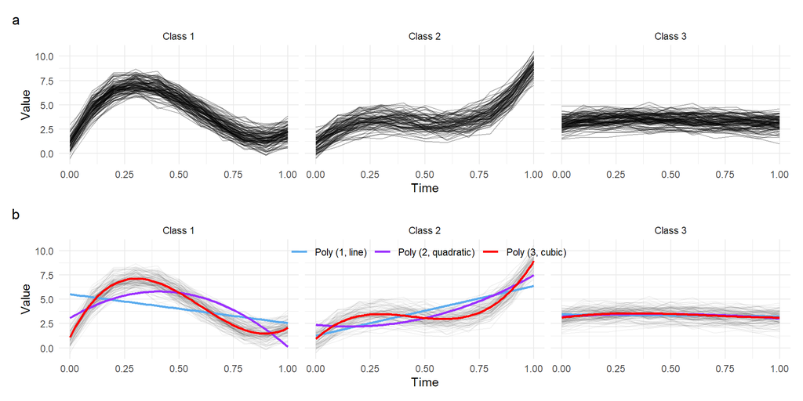

```r
three_class_sim <- latrend::generateLongData(sizes = c(100, 80, 110), id = "Id",
                            cluster = ~splines::bs(Time, df = 3),
                            clusterCoefs = cbind(c(1, 15, -3, 1),
                                                 c(1, 7, -4,8),
                                                 c(3.2, 1, 0,0)),
                            noiseScales = c(0.4, 0.4, 0.3),
                            randomScales = cbind(0.6, 0.6, 0.5),
                            clusterNames = c("Class 1", "Class 2", "Class 3"))

figX2a<-ggplot(three_class_sim, aes(Time, Value, group = Id))+
  geom_line(alpha = 0.3)+
  theme_minimal()

figX2b<-ggplot(three_class_sim, aes(Time, Value, group = Id))+
  geom_line(alpha = 0.3)+
  theme_minimal()+
  facet_grid(~Class)


figX2c<-ggplot(three_class_sim, aes(Time, Value, group = Id))+
  geom_line(alpha = 0.05)+
  geom_smooth(aes(group = Class, color = "Poly (1, line)"), method = "lm", se = F, formula = y~poly(x,1), size = 1, show.legend = T)+
  geom_smooth(aes(group = Class, color = "Poly (2, quadratic)"), method = "lm", se = F, formula = y~poly(x,2), size = 1)+
  geom_smooth(aes(group = Class, color = "Poly (3, cubic)"), method = "lm", se = F, formula = y~poly(x,3), size = 1)+
  theme_minimal()+
  scale_color_manual(values=c("steelblue2", "purple1", "red"))+
  theme(legend.position = c(0.5,0.9), legend.title = element_blank(),
        legend.direction = "horizontal")+
  facet_grid(~Class)


figX2<-figX2b+figX2c

figX2<-figX2+plot_layout(nrow = 2)+plot_annotation(tag_levels = "a")

figX2
```

```r
ggsave("figures/figX2.png", width = 8, height = 5)
```